# Como leer matemáticas: Conjuntos

## Conjuntos

Los solemos representar de forma gráfica mediante circulos y solemos encerrarlo dentro de un rectangulo. Tenemos los conjuntos

- A
- B
- Ω Conjunto universo
- `|` Tal que

[figure not shown]

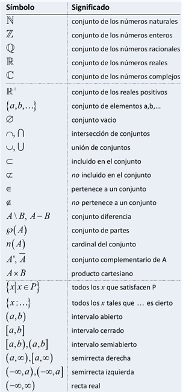

- **A∪B:** unión de dos conjuntos. [Le corresponde 'O'] Entonces los elementos que estén en A o B. Es decir se integran los 2 conjuntos para formar uno nuevo.
- **A∩B:** intersección de dos conjuntos. [Le corresponde 'Y'] Aquí los elementos que estén en A 'Y' B son los que son pertenecientes a la intersección, forzosamente tienen que estar en ambos conjuntos.
- **∅={}**: Conjunto vacío

**a ∈ A** : Un elemento 'a' pertenece al conjunto **A**.  
OJO: Los conjuntos se suelen representar con letras mayusculas

### Ejemplo

A={1,2,3,4} Conjunto A  
B={3,4,5,6} Conjunto B

### Conjunto de números

- ℕ Conjunto de números naturales.  
  ℕ={1,2,3,4,...| n≠0}  
  `| n≠0` Esto nos dice, tal que `n` diferente de `0`.
- ℤ Conjunto de números enteros  
  ℤ={..,-2,-1,0,1,2,..}  
  Esto nos dice que son los números enteros, pero en pasos de una unidad
- ℚ Conjunto de números racionales  
  ℚ={a/b | a,b ∈ ℤ,b≠0}  
  `| a,b ∈ ℤ,b≠0`  
  Esto nos dice; **tal que a y b pertenecen al conjunto de los números enteros y b diferente de 0**
- I Conjunto de número irracionales  
  I={π,e,√5,Φ...}  
  Este tipo de conjuntos no se puede representar como en una forma a los anteriores, es decir ni como fracción, entero o natural. Puede tener una representación decimal periodica o no.
- ℝ Conjunto de números reales  
  ℝ={ℕ ∪ ℤ ∪ ℚ ∪ I}  
  El conjunto de los números reales es la unión de números naturales, enteros, racionales e irracionales
  - ℝ+ Números reales positivos
  - ℝ - Números reales negativos

### Simbolos de Función / Aplicación

**f:Χ→Υ** Existe una función que nos lleva de un conjunto `Χ` a un conjunto `Υ`.

Por ejemplo:  
f:ℝ → ℝ+ = f(x)= abs(x)= |x|

Existe una función `tal que`(los puntos se leen también como 'tal que') nos va a llevar de los `ℝ→ℝ+`.

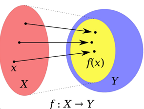

### Explicación

Podemos ver en la parte de abajo los *símbolos de función / aplicación* y nos dice; que nos va a llevar de un **conjunto X** (Conjunto en rojo) a un **conjunto Y** (Conjunto en morado) y de hecho a donde nos lleva nuestra función `f(x)` es al **conjunto f(x)** (Conjunto en amarillo).

### Dominio escrito como conjunto

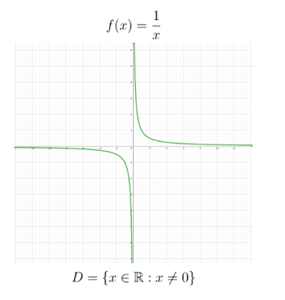

Son todas las `x's` que pertenecen a los Reales `ℝ` tal que `x` sea diferente de `0`. Esa es la única restricción.

En un lenguaje formal es:  
`D = {x ∈ ℝ | x ≠ 0}`  
El dominio de la función es igual al conjunto de `x` que pertenece a los números reales, tal que `x` es diferente de `0`.